# Predicting Cardiovascular Disease Using Lifestyle and Clinical Risk Factors

**Module:** M505 Intro to AI and Machine Learning  
**Assessment:** Individual Project  
**Student:** *GH1056684 - Zainab Awad Alzubair Mohammed*  
**Dataset Source:** https://www.kaggle.com/datasets/sulianova/cardiovascular-disease-dataset

## Introduction

**Can we predict if a person has cardiovascular disease using clinical report and lifestyle features?**

One of the most common reasons for death and illness across the world is cardiovascular disease. Finding people who are at high risk early on can help with preventive healthcare, improve long-term outcomes, and ease the strain on healthcare systems. In reality, cardiovascular risk is affected by a mix of demographic, clinical, and lifestyle factors, not just one on its own.

This project creates a complete machine learning pipeline that uses a structured dataset with information like age, cholesterol, blood pressure, gender, glucose level, smoking status, alcohol use, physical activity, height, and weight to predict heart disease. The project involves looking at the data, cleaning it up, adding new features, doing exploratory analysis, training the model, tuning the hyperparameters, and then evaluating and interpreting the results.

One of the primary Motivations for this Topic is the role of modifiable risk factors such as smoking, lack of physical activity and obesity. So, the project is not only about how well the model can predict things, but also about figuring out which variables are the most useful in the final model.

## Problem Statement

The aim of this project is to develop a machine learning model that can predict if a person has cardiovascular disease based on their medical history and lifestyle.

This problem is classified as a binary classification problem:

**Target = 1:** there is cardiovascular disease  
**Target = 0:** there is no ccardiovascular disease

From a practical standpoint, a predictive model of this nature could facilitate early screening and stratification of risk. However, since this is a health-related task, the model needs to be carefully tested, especially to see how well it can find positive cases.

## Dataset Description

For this project i used the **Cardiovascular Disease Dataset** (`cardio_train.csv`). It has 70,000 observations, 13 original columns and the following original variables:

- `id`: unique record identifier
- `age`: age in days
- `gender`: gender code
- `height`: height in centimetres
- `weight`: weight in kilograms
- `ap_hi`: systolic blood pressure
- `ap_lo`: blood pressure when the heart is at rest
- `cholesterol`: cholesterol category
- `gluc`: glucose category
- `smoke`: smoking status
- `alco`: alcohol consumption status
- `active`: status of physical activity
- `cardio`: target variable indicating cardiovascular disease

This dataset has a clear predictive goal, and a wide range of variables that reflect both clinical and behavioral risk factors. It also makes it possible to do useful feature engineering, like figuring out **Body Mass Index (BMI)** from height and weight.

**Import required Libraries**

```python
import warnings
warnings.filterwarnings("ignore")

import numpy as np
import pandas as pd
# Visualization libraries
import matplotlib.pyplot as plt
import seaborn as sns
# Machine learning tools
from sklearn.model_selection import train_test_split, GridSearchCV, StratifiedKFold
from sklearn.pipeline import Pipeline
from sklearn.compose import ColumnTransformer
from sklearn.impute import SimpleImputer
from sklearn.preprocessing import StandardScaler
from sklearn.metrics import (
    accuracy_score, precision_score, recall_score, f1_score,
    roc_auc_score, classification_report, confusion_matrix,
    ConfusionMatrixDisplay, roc_curve
)

from sklearn.linear_model import LogisticRegression
from sklearn.neighbors import KNeighborsClassifier
from sklearn.ensemble import RandomForestClassifier

sns.set_theme(style="whitegrid")
pd.set_option("display.max_columns", None)
```

## Data Importing

```python
df = pd.read_csv("./cardio_train.csv", sep=";")
# Display first few rows to understand structure
df.head()
```

|  | id | age | gender | height | weight | ap_hi | ap_lo | cholesterol | gluc | smoke | alco | active | cardio |
| --- | --- | --- | --- | --- | --- | --- | --- | --- | --- | --- | --- | --- | --- |
| 0 | 0 | 18393 | 2 | 168 | 62.0 | 110 | 80 | 1 | 1 | 0 | 0 | 1 | 0 |
| 1 | 1 | 20228 | 1 | 156 | 85.0 | 140 | 90 | 3 | 1 | 0 | 0 | 1 | 1 |
| 2 | 2 | 18857 | 1 | 165 | 64.0 | 130 | 70 | 3 | 1 | 0 | 0 | 0 | 1 |
| 3 | 3 | 17623 | 2 | 169 | 82.0 | 150 | 100 | 1 | 1 | 0 | 0 | 1 | 1 |
| 4 | 4 | 17474 | 1 | 156 | 56.0 | 100 | 60 | 1 | 1 | 0 | 0 | 0 | 0 |

## Initial Examination for the dataset

First step is to inspect the basic features like size, and structure of the dataset. It helps to make sure that the variables were loaded correctly and shows any clear problems with the data quality before modeling starts.

```python
print("Dataset shape:", df.shape)
print("\nColumns:")
print(df.columns.tolist())

print("\nData types:")
display(df.dtypes)
# Check for missing values
print("\nMissing values:")
display(df.isnull().sum())

print("\nSummary statistics:")
display(df.describe().T)
```

```
Dataset shape: (70000, 13)

Columns:
['id', 'age', 'gender', 'height', 'weight', 'ap_hi', 'ap_lo', 'cholesterol', 'gluc', 'smoke', 'alco', 'active', 'cardio']

Data types:
```

|  | 0 |
| --- | --- |
| id | int64 |
| age | int64 |
| gender | int64 |
| height | int64 |
| weight | float64 |
| ap_hi | int64 |
| ap_lo | int64 |
| cholesterol | int64 |
| gluc | int64 |
| smoke | int64 |
| alco | int64 |
| active | int64 |
| cardio | int64 |

**dtype:** object

```
Missing values:
```

|  | 0 |
| --- | --- |
| id | 0 |
| age | 0 |
| gender | 0 |
| height | 0 |
| weight | 0 |
| ap_hi | 0 |
| ap_lo | 0 |
| cholesterol | 0 |
| gluc | 0 |
| smoke | 0 |
| alco | 0 |
| active | 0 |
| cardio | 0 |

**dtype:** int64

```
Summary statistics:
```

|  | count | mean | std | min | 25% | 50% | 75% | max |
| --- | --- | --- | --- | --- | --- | --- | --- | --- |
| id | 70000.0 | 49972.419900 | 28851.302323 | 0.0 | 25006.75 | 50001.5 | 74889.25 | 99999.0 |
| age | 70000.0 | 19468.865814 | 2467.251667 | 10798.0 | 17664.00 | 19703.0 | 21327.00 | 23713.0 |
| gender | 70000.0 | 1.349571 | 0.476838 | 1.0 | 1.00 | 1.0 | 2.00 | 2.0 |
| height | 70000.0 | 164.359229 | 8.210126 | 55.0 | 159.00 | 165.0 | 170.00 | 250.0 |
| weight | 70000.0 | 74.205690 | 14.395757 | 10.0 | 65.00 | 72.0 | 82.00 | 200.0 |
| ap_hi | 70000.0 | 128.817286 | 154.011419 | -150.0 | 120.00 | 120.0 | 140.00 | 16020.0 |
| ap_lo | 70000.0 | 96.630414 | 188.472530 | -70.0 | 80.00 | 80.0 | 90.00 | 11000.0 |
| cholesterol | 70000.0 | 1.366871 | 0.680250 | 1.0 | 1.00 | 1.0 | 2.00 | 3.0 |
| gluc | 70000.0 | 1.226457 | 0.572270 | 1.0 | 1.00 | 1.0 | 1.00 | 3.0 |
| smoke | 70000.0 | 0.088129 | 0.283484 | 0.0 | 0.00 | 0.0 | 0.00 | 1.0 |
| alco | 70000.0 | 0.053771 | 0.225568 | 0.0 | 0.00 | 0.0 | 0.00 | 1.0 |
| active | 70000.0 | 0.803729 | 0.397179 | 0.0 | 1.00 | 1.0 | 1.00 | 1.0 |
| cardio | 70000.0 | 0.499700 | 0.500003 | 0.0 | 0.00 | 0.0 | 1.00 | 1.0 |

### Initial Interpretation

After the initial inspection, i found that there are no missing values in the raw dataset, However this does not guarantee that the data is clean so I will do additional checks

Also, The variables are numerical or binary-coded categorical fields.

lastly, I observed that the `age` is stored in **days** in the dataset, not in years, so for better interpretability, I will convert it to years in the next step

## Feature Engineering

### 1. Age in Years

The age variable in the dataset is measured in days, which is difficult to interpret directly. I converted it into years for the purpose of clarity.

### 2. Body Mass Index (BMI)

I calculated the BMI from height and weight:

[ BMI = \frac{weight\ (kg)}{height\ (m)^2} ]

I added this feature because obesity is more accurately represented through BMI than only through body weight.

```python
# Convert age from days to years for better interpretability
df["age_years"] = df["age"] / 365.25
# Convert height to meters
df["height_m"] = df["height"] / 100
# Create BMI feature (important for obesity analysis)
df["bmi"] = df["weight"] / (df["height_m"] ** 2)

df[["age", "age_years", "height", "weight", "bmi"]].head()
```

|  | age | age_years | height | weight | bmi |
| --- | --- | --- | --- | --- | --- |
| 0 | 18393 | 50.357290 | 168 | 62.0 | 21.967120 |
| 1 | 20228 | 55.381246 | 156 | 85.0 | 34.927679 |
| 2 | 18857 | 51.627652 | 165 | 64.0 | 23.507805 |
| 3 | 17623 | 48.249144 | 169 | 82.0 | 28.710479 |
| 4 | 17474 | 47.841205 | 156 | 56.0 | 23.011177 |

## Data Quality Checks and Cleaning

The dataset is free of missing values; however, in healthcare datasets, unrealistic data may be present.

I removed unrealistic height, weight, blood pressure, and BMI values for data reliability.

```python
invalid_height = (df["height"] < 100) | (df["height"] > 250)
invalid_weight = (df["weight"] < 30) | (df["weight"] > 250)
invalid_bp_range = (df["ap_hi"] < 50) | (df["ap_hi"] > 250) | (df["ap_lo"] < 30) | (df["ap_lo"] > 200)
invalid_bp_order = df["ap_hi"] <= df["ap_lo"]
invalid_bmi = (df["bmi"] < 10) | (df["bmi"] > 80)

print("Invalid height rows:", invalid_height.sum())
print("Invalid weight rows:", invalid_weight.sum())
print("Invalid blood pressure range rows:", invalid_bp_range.sum())
print("Invalid blood pressure order rows:", invalid_bp_order.sum())
print("Invalid BMI rows:", invalid_bmi.sum())
```

```
Invalid height rows: 29
Invalid weight rows: 7
Invalid blood pressure range rows: 1219
Invalid blood pressure order rows: 1236
Invalid BMI rows: 39
```

```python
df_clean = df.loc[~(invalid_height | invalid_weight | invalid_bp_range | invalid_bp_order | invalid_bmi)].copy()

print("Original shape:", df.shape)
print("Cleaned shape:", df_clean.shape)
print("Rows removed:", df.shape[0] - df_clean.shape[0])

df = df_clean.copy()
```

```
Original shape: (70000, 16)
Cleaned shape: (68638, 16)
Rows removed: 1362
```

### Cleaning Interpretation

I removed incorrect records, likely due to data entry or measurement errors, to prevent skewing summary statistics and maintain prediction model quality.

## Exploratory Data Analysis

In this section, I related the prediction task to the topic motivation by examining the relationship between variables such as smoking, obesity, glucose, cholesterol, and physical activity with cardiovascular disease.

```python
print("Target counts:")
display(df["cardio"].value_counts())

print("\nTarget proportions:")
display(df["cardio"].value_counts(normalize=True))

# This tells how many 0s and 1s we have.
# if one class is much bigger than the other, accuracy can be misleading
# the dataset is fairly balanced
```

```
Target counts:
```

| cardio | count |
| --- | --- |
| 0 | 34682 |
| 1 | 33956 |

**dtype:** int64

```
Target proportions:
```

| cardio | proportion |
| --- | --- |
| 0 | 0.505289 |
| 1 | 0.494711 |

**dtype:** float64

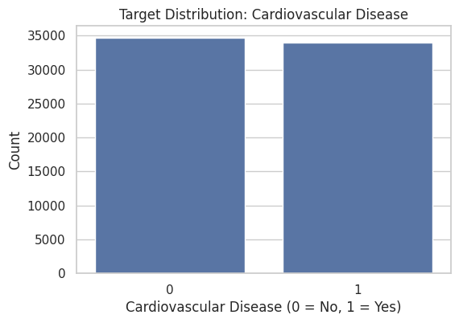

```python
plt.figure(figsize=(6,4))
sns.countplot(data=df, x="cardio")
plt.title("Target Distribution: Cardiovascular Disease")
plt.xlabel("Cardiovascular Disease (0 = No, 1 = Yes)")
plt.ylabel("Count")
plt.show()
```

### Target Distribution Interpretation

I checked the target distribution for a proper balance between classes. A relatively balanced target distribution is desirable for training stability, and this minimizes the need for advanced class balancing techniques. However, in the case where one class is highly dominant over the other, accuracy alone may not be sufficient, which is why recall and F1-score are also included in this project.

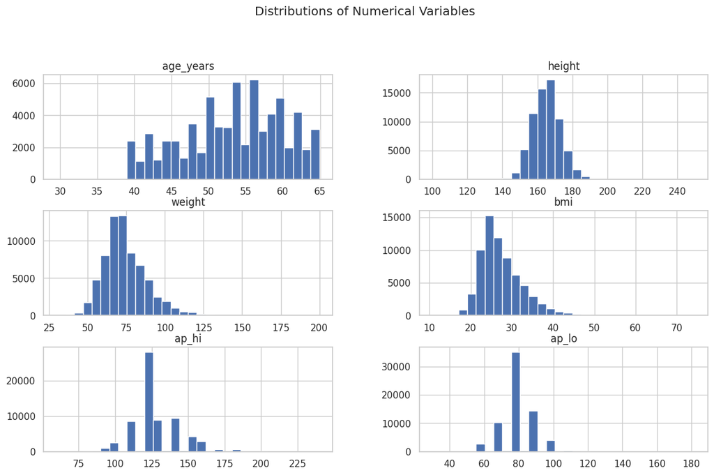

```python
num_cols = ["age_years", "height", "weight", "bmi", "ap_hi", "ap_lo"]

df[num_cols].hist(figsize=(14,8), bins=30)
plt.suptitle("Distributions of Numerical Variables", y=1.02)
plt.show()
```

### Numerical Variable Interpretation

These plots show the range for the main numeric variables. The age and BMI variables are particularly important because they are likely to have a relationship with cardiovascular risk. The Blood pressure variables are also likely to have a strong relationship because high blood pressure is a well-established risk factor.

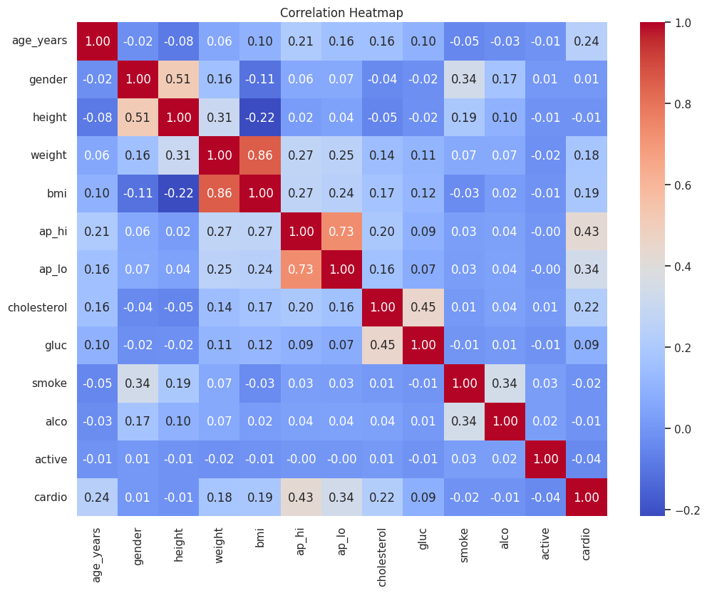

```python
corr_cols = [
    "age_years", "gender", "height", "weight", "bmi",
    "ap_hi", "ap_lo", "cholesterol", "gluc",
    "smoke", "alco", "active", "cardio"
]

plt.figure(figsize=(12,9))
sns.heatmap(df[corr_cols].corr(), annot=True, cmap="coolwarm", fmt=".2f")
plt.title("Correlation Heatmap")
plt.show()

# This shows relationships between variables.
```

### Correlation Interpretation

I applied a correlation heatmap becuse because features such as age, blood pressure, cholesterol, glucose, and BMI may have a strong positive correlation with cardiovascular disease and could potentially be important contributors to the prediction.

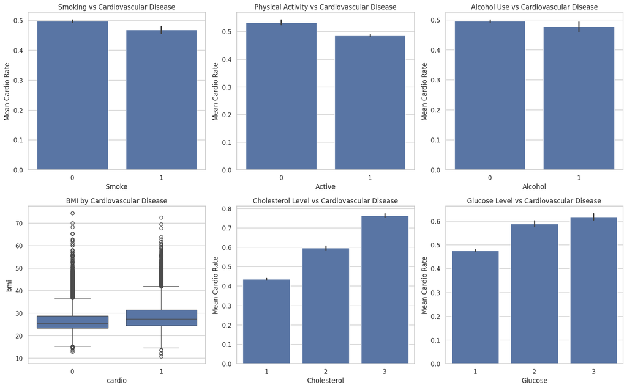

```python
fig, axes = plt.subplots(2, 3, figsize=(16, 10))

sns.barplot(data=df, x="smoke", y="cardio", ax=axes[0,0])
axes[0,0].set_title("Smoking vs Cardiovascular Disease")
axes[0,0].set_xlabel("Smoke")
axes[0,0].set_ylabel("Mean Cardio Rate")

sns.barplot(data=df, x="active", y="cardio", ax=axes[0,1])
axes[0,1].set_title("Physical Activity vs Cardiovascular Disease")
axes[0,1].set_xlabel("Active")
axes[0,1].set_ylabel("Mean Cardio Rate")

sns.barplot(data=df, x="alco", y="cardio", ax=axes[0,2])
axes[0,2].set_title("Alcohol Use vs Cardiovascular Disease")
axes[0,2].set_xlabel("Alcohol")
axes[0,2].set_ylabel("Mean Cardio Rate")

sns.boxplot(data=df, x="cardio", y="bmi", ax=axes[1,0])
axes[1,0].set_title("BMI by Cardiovascular Disease")

sns.barplot(data=df, x="cholesterol", y="cardio", ax=axes[1,1])
axes[1,1].set_title("Cholesterol Level vs Cardiovascular Disease")
axes[1,1].set_xlabel("Cholesterol")
axes[1,1].set_ylabel("Mean Cardio Rate")

sns.barplot(data=df, x="gluc", y="cardio", ax=axes[1,2])
axes[1,2].set_title("Glucose Level vs Cardiovascular Disease")
axes[1,2].set_xlabel("Glucose")
axes[1,2].set_ylabel("Mean Cardio Rate")

plt.tight_layout()
plt.show()
```

### Risk-Factor Interpretation

This will provide a clearer view of the plots for the project’s topic. If cardiovascular diseases are common among smokers, less active individuals, individuals with higher BMI, and individuals with higher levels of cholesterol and glucose, then the results of the exploratory analysis affirm the rationale for the inclusion of the variables for prediction.

## Data Preparation for Modelling

The target variable is `cardio`. The rest of the predictors will be used as input variables, but a few modifications will be made:

- `id` is removed since it is an identifier
- `age` in days is removed since `age_years` is more interpretable
- `helper` `height_m` is removed since it was only used for the calculation of `BMI`

The data is then divided into a training set and a test set so that the performance of the final model can be evaluated.

```python
# Define features (X) and target variable (y)
X = df.drop(columns=["id", "cardio", "age", "height_m"])
y = df["cardio"]

print("Feature columns:")
print(X.columns.tolist())

print("\nTarget distribution:")
display(y.value_counts())
```

```
Feature columns:
['gender', 'height', 'weight', 'ap_hi', 'ap_lo', 'cholesterol', 'gluc', 'smoke', 'alco', 'active', 'age_years', 'bmi']

Target distribution:
```

| cardio | count |
| --- | --- |
| 0 | 34682 |
| 1 | 33956 |

**dtype:** int64

```python
numeric_features = X.columns.tolist()
# Split data into training and testing sets (80/20 split)
X_train, X_test, y_train, y_test = train_test_split(
    X, y,
    test_size=0.2,
    random_state=42,
    stratify=y
)

print("X_train shape:", X_train.shape)
print("X_test shape:", X_test.shape)
print("y_train shape:", y_train.shape)
print("y_test shape:", y_test.shape)
```

```
X_train shape: (54910, 12)
X_test shape: (13728, 12)
y_train shape: (54910,)
y_test shape: (13728,)
```

## Preprocessing Strategy

I did preprocessing to guarantee that transformations are applied uniformly across both training and testing data.

The preprocessing steps are:

- **median imputation** for numeric variables, which is a robust imputation method even when the missing values are limited
- **standardisation** using `StandardScaler`, which is particularly helpful for KNN and Logistic Regression

This structured pipeline also helps avoid data leakage

```python
numeric_transformer = Pipeline(steps=[
    ("imputer", SimpleImputer(strategy="median")),
    ("scaler", StandardScaler())
])

preprocessor = ColumnTransformer(
    transformers=[
        ("num", numeric_transformer, numeric_features)
    ]
)
```

## Model Selection

In this Pipline, three machine learning models are selected for comparison:

### 1. Logistic Regression

I used this model as a baseline because it is simple, efficient, and interpretable.

### 2. K-Nearest Neighbours (KNN)

I used KNN as a distance-based method that can capture local similarity patterns in the data. However, its performance can depend strongly on the choice of `k` and the feature scale.

### 3. Random Forest

I chose the Random Forest method because it can model and handle more complex and non-linear relationships. It can work well for structured tabular data and also provide feature importance scores.

## Hyperparameter Tuning

Instead of using the default settings for the parameters, I have used hyperparameter tuning using **GridSearchCV** and cross-validation for the training set of each model. This will ensure that the performance of the model is enhanced by using the best parameters rather than default parameters.

I have used the **F1** score as the evaluation metric for the model because it provides a balanced score for precision and recall. This is important in the healthcare industry because not only should the model make correct predictions, but it should also ensure that there are minimum false positives and false negatives.

```python
# Create preprocessing + model pipeline
log_reg_pipe = Pipeline(steps=[
    ("preprocessor", preprocessor),
    ("model", LogisticRegression(max_iter=2000, random_state=42))
])

knn_pipe = Pipeline(steps=[
    ("preprocessor", preprocessor),
    ("model", KNeighborsClassifier())
])

rf_pipe = Pipeline(steps=[
    ("preprocessor", preprocessor),
    ("model", RandomForestClassifier(random_state=42, n_jobs=-1))
])

log_reg_params = {
    "model__C": [0.01, 0.1, 1, 10],
    "model__solver": ["liblinear", "lbfgs"]
}

knn_params = {
    "model__n_neighbors": [3, 5, 7, 9, 11],
    "model__weights": ["uniform", "distance"],
    "model__metric": ["euclidean", "manhattan"]
}

rf_params = {
    "model__n_estimators": [100, 200],
    "model__max_depth": [None, 10, 20],
    "model__min_samples_split": [2, 5],
    "model__min_samples_leaf": [1, 2]
}

cv = StratifiedKFold(n_splits=5, shuffle=True, random_state=42)
```

```python
log_reg_pipe = Pipeline(steps=[
    ("preprocessor", preprocessor),
    ("model", LogisticRegression(max_iter=2000, random_state=42))
])

knn_pipe = Pipeline(steps=[
    ("preprocessor", preprocessor),
    ("model", KNeighborsClassifier())
])

rf_pipe = Pipeline(steps=[
    ("preprocessor", preprocessor),
    ("model", RandomForestClassifier(random_state=42, n_jobs=-1))
])
# Define parameter grid for Logistic Regression
log_reg_params = {
    "model__C": [0.1, 1, 10],
    "model__solver": ["liblinear"]
}

knn_params = {
    "model__n_neighbors": [5, 9],
    "model__weights": ["uniform", "distance"]
}

rf_params = {
    "model__n_estimators": [100],
    "model__max_depth": [10, None],
    "model__min_samples_split": [2, 5]
}
# Use Stratified K-Fold to preserve class distribution
cv = StratifiedKFold(n_splits=3, shuffle=True, random_state=42)
# Perform grid search to find best parameters
log_reg_grid = GridSearchCV(
    estimator=log_reg_pipe,
    param_grid=log_reg_params,
    scoring="f1",
    cv=cv,
    n_jobs=-1
)

knn_grid = GridSearchCV(
    estimator=knn_pipe,
    param_grid=knn_params,
    scoring="f1",
    cv=cv,
    n_jobs=-1
)

rf_grid = GridSearchCV(
    estimator=rf_pipe,
    param_grid=rf_params,
    scoring="f1",
    cv=cv,
    n_jobs=-1
)
# Train model using grid search
print("Training Logistic Regression...")
log_reg_grid.fit(X_train, y_train)

print("Training KNN...")
knn_grid.fit(X_train, y_train)

print("Training Random Forest...")
rf_grid.fit(X_train, y_train)
```

```
Training Logistic Regression...
Training KNN...
Training Random Forest...
```

[output not shown]

```python
print("Best Logistic Regression parameters:")
print(log_reg_grid.best_params_)
print("Best Logistic Regression CV F1:", log_reg_grid.best_score_)

print("\nBest KNN parameters:")
print(knn_grid.best_params_)
print("Best KNN CV F1:", knn_grid.best_score_)

print("\nBest Random Forest parameters:")
print(rf_grid.best_params_)
print("Best Random Forest CV F1:", rf_grid.best_score_)
```

```
Best Logistic Regression parameters:
{'model__C': 10, 'model__solver': 'liblinear'}
Best Logistic Regression CV F1: 0.7080475721314471

Best KNN parameters:
{'model__n_neighbors': 9, 'model__weights': 'uniform'}
Best KNN CV F1: 0.6983194921300081

Best Random Forest parameters:
{'model__max_depth': 10, 'model__min_samples_split': 2, 'model__n_estimators': 100}
Best Random Forest CV F1: 0.7153134931389058
```

## Model Evaluation on the Test Set

The best-tuned models are evaluated on the test set using metrics: Accuracy, Precision, Recall, F1-score, and ROC-AUC. Recall is crucial as missing a high-risk individual is more critical than sending a false warning.

```python
best_models = {
    "Logistic Regression": log_reg_grid.best_estimator_,
    "KNN": knn_grid.best_estimator_,
    "Random Forest": rf_grid.best_estimator_
}

results = []

for name, model in best_models.items():
  # Predict on test data
    y_pred = model.predict(X_test)
    y_prob = model.predict_proba(X_test)[:, 1]

    results.append({
        "Model": name,
        "Accuracy": accuracy_score(y_test, y_pred),
        "Precision": precision_score(y_test, y_pred),
        "Recall": recall_score(y_test, y_pred),
        "F1": f1_score(y_test, y_pred),
        "ROC_AUC": roc_auc_score(y_test, y_prob)
    })

results_df = pd.DataFrame(results).sort_values(by="F1", ascending=False)
results_df
```

|  | Model | Accuracy | Precision | Recall | F1 | ROC_AUC |
| --- | --- | --- | --- | --- | --- | --- |
| 2 | Random Forest | 0.733100 | 0.759244 | 0.674275 | 0.714241 | 0.800037 |
| 1 | KNN | 0.712413 | 0.717854 | 0.689736 | 0.703515 | 0.761374 |
| 0 | Logistic Regression | 0.722975 | 0.749249 | 0.661316 | 0.702542 | 0.790379 |

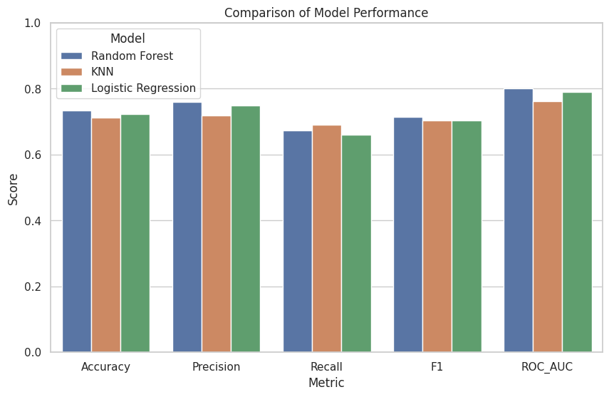

```python
results_melted = results_df.melt(
    id_vars="Model",
    value_vars=["Accuracy", "Precision", "Recall", "F1", "ROC_AUC"]
)

plt.figure(figsize=(10,6))
sns.barplot(data=results_melted, x="variable", y="value", hue="Model")
plt.title("Comparison of Model Performance")
plt.xlabel("Metric")
plt.ylabel("Score")
plt.ylim(0, 1)
plt.show()
```

```
======================================================================
Logistic Regression
======================================================================
              precision    recall  f1-score   support

           0       0.70      0.78      0.74      6937
           1       0.75      0.66      0.70      6791

    accuracy                           0.72     13728
   macro avg       0.73      0.72      0.72     13728
weighted avg       0.73      0.72      0.72     13728
```

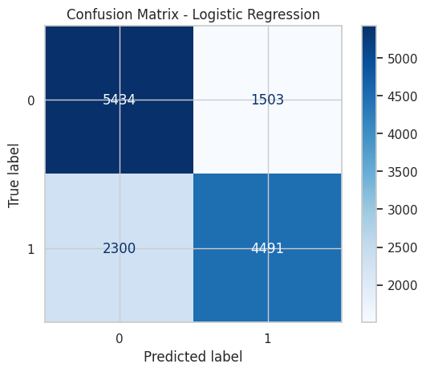

```
======================================================================
KNN
======================================================================
              precision    recall  f1-score   support

           0       0.71      0.73      0.72      6937
           1       0.72      0.69      0.70      6791

    accuracy                           0.71     13728
   macro avg       0.71      0.71      0.71     13728
weighted avg       0.71      0.71      0.71     13728
```

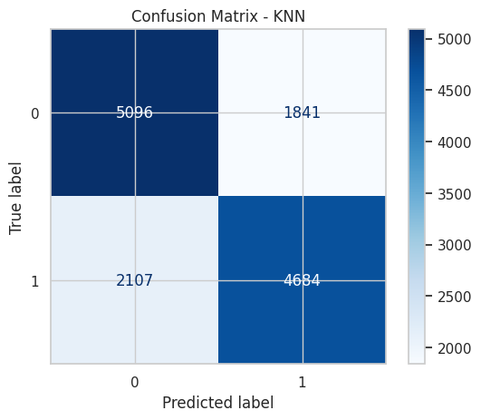

```
======================================================================
Random Forest
======================================================================
              precision    recall  f1-score   support

           0       0.71      0.79      0.75      6937
           1       0.76      0.67      0.71      6791

    accuracy                           0.73     13728
   macro avg       0.74      0.73      0.73     13728
weighted avg       0.74      0.73      0.73     13728
```

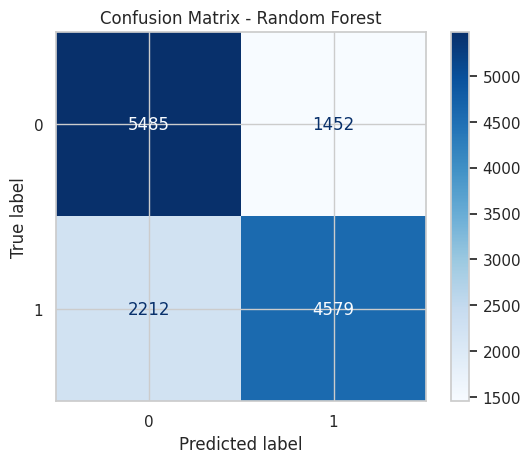

```python
for name, model in best_models.items():
    print("=" * 70)
    print(name)
    print("=" * 70)

    y_pred = model.predict(X_test)
    print(classification_report(y_test, y_pred))

    cm = confusion_matrix(y_test, y_pred)
    disp = ConfusionMatrixDisplay(confusion_matrix=cm)
    disp.plot(cmap="Blues")
    plt.title(f"Confusion Matrix - {name}")
    plt.show()
```

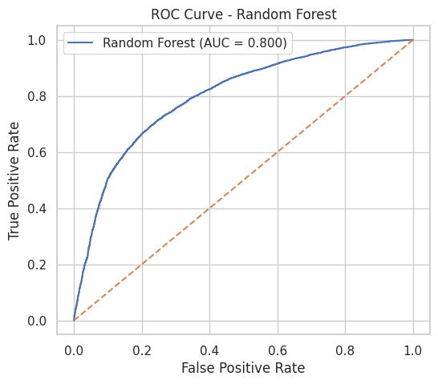

```python
best_model_name = results_df.iloc[0]["Model"]
best_model = best_models[best_model_name]

y_prob_best = best_model.predict_proba(X_test)[:, 1]
fpr, tpr, thresholds = roc_curve(y_test, y_prob_best)

plt.figure(figsize=(6,5))
plt.plot(fpr, tpr, label=f"{best_model_name} (AUC = {roc_auc_score(y_test, y_prob_best):.3f})")
plt.plot([0,1], [0,1], linestyle="--")
plt.xlabel("False Positive Rate")
plt.ylabel("True Positive Rate")
plt.title(f"ROC Curve - {best_model_name}")
plt.legend()
plt.show()
```

### Evaluation Interpretation

In my opinion, the best model should not simply be determined by its accuracy. In a healthcare-related problem, a model with a higher recall or F1-score might be more desirable even if it has lower accuracy. Therefore, the final evaluation should take into account several aspects.

If Random Forest turns out to be the best model, it could imply that the relationship between the predictors and cardiovascular disease is at least partially non-linear. If Logistic Regression performs competitively, that would indicate that a simpler and more interpretable model may still be viable.

## Improving Recall in a Healthcare Context

In healthcare, improving model recall is crucial to minimize false negatives for cardiovascular disease. Lowering the classification threshold enhances recall, but may reduce precision due to increased false positives.

```python
# Threshold tuning for the best model
thresholds_to_test = [0.50, 0.45, 0.40, 0.35]

recall_results = []

for t in thresholds_to_test:
    y_pred_t = (y_prob_best >= t).astype(int)
    recall_results.append({
        "Threshold": t,
        "Precision": precision_score(y_test, y_pred_t),
        "Recall": recall_score(y_test, y_pred_t),
        "F1": f1_score(y_test, y_pred_t),
        "Accuracy": accuracy_score(y_test, y_pred_t)
    })

recall_results_df = pd.DataFrame(recall_results)
recall_results_df
```

|  | Threshold | Precision | Recall | F1 | Accuracy |
| --- | --- | --- | --- | --- | --- |
| 0 | 0.50 | 0.759244 | 0.674275 | 0.714241 | 0.733100 |
| 1 | 0.45 | 0.728851 | 0.729495 | 0.729173 | 0.731935 |
| 2 | 0.40 | 0.699654 | 0.774555 | 0.735202 | 0.723995 |
| 3 | 0.35 | 0.662005 | 0.836401 | 0.739054 | 0.707823 |

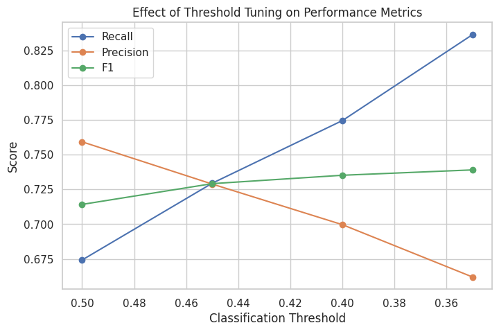

```python
plt.figure(figsize=(8,5))
plt.plot(recall_results_df["Threshold"], recall_results_df["Recall"], marker="o", label="Recall")
plt.plot(recall_results_df["Threshold"], recall_results_df["Precision"], marker="o", label="Precision")
plt.plot(recall_results_df["Threshold"], recall_results_df["F1"], marker="o", label="F1")
plt.gca().invert_xaxis()
plt.title("Effect of Threshold Tuning on Performance Metrics")
plt.xlabel("Classification Threshold")
plt.ylabel("Score")
plt.legend()
plt.show()
```

### Recall Improvement Interpretation

Threshold tuning enhances recall in cardiovascular case identification by lowering the threshold, leading to better true positive detection. This improvement, however, decreases precision, resulting in an increase in false positives. For the sake of this assignment, the original best model remains the primary model, while threshold tuning serves to illustrate the recall-precision trade-off in healthcare.

## Feature Importance and Explainability

One advantage that Random Forest has is that it is capable of producing feature importance scores. These scores show which features contribute most to the predictions within a model.

This is especially important for this project because not only is the project trying to make a prediction about cardiovascular disease, but it is also trying to see if features such as BMI, blood pressure, smoking, glucose, cholesterol, and physical activity are important to the decision.

```python
best_rf = rf_grid.best_estimator_
rf_model = best_rf.named_steps["model"]
# Extract feature importance from Random
# Create dataframe for better visualization
feature_importance_df = pd.DataFrame({
    "Feature": numeric_features,
    "Importance": rf_model.feature_importances_
}).sort_values(by="Importance", ascending=False)

feature_importance_df
```

|  | Feature | Importance |
| --- | --- | --- |
| 3 | ap_hi | 0.404687 |
| 4 | ap_lo | 0.209885 |
| 10 | age_years | 0.136354 |
| 5 | cholesterol | 0.086298 |
| 11 | bmi | 0.062914 |
| 2 | weight | 0.043600 |
| 1 | height | 0.023909 |
| 6 | gluc | 0.012640 |
| 9 | active | 0.007672 |
| 0 | gender | 0.004231 |
| 7 | smoke | 0.004193 |
| 8 | alco | 0.003616 |

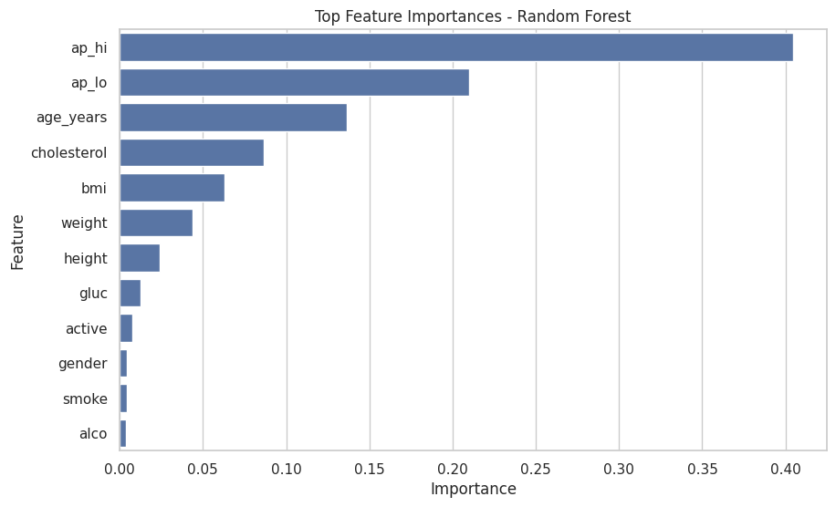

```python
plt.figure(figsize=(10,6))
sns.barplot(data=feature_importance_df.head(12), x="Importance", y="Feature")
plt.title("Top Feature Importances - Random Forest")
plt.xlabel("Importance")
plt.ylabel("Feature")
plt.show()
```

## Critical Evaluation

In this section, I evaluate the pipeline’s strengths, limitations, and practical implications.

**Limitations** The dataset lacks important features such as family history, diet, stress, and genetics, limiting the model’s ability to fully capture cardiovascular risk. As the data is observational, it identifies correlations rather than causation. Model performance is moderate (~73% accuracy), indicating room for improvement, particularly in recall. Furthermore, the model has not been validated on external datasets, raising concerns about generalizability.

**Overall Judgement** Overall, the project demonstrates a solid application of machine learning in healthcare. While the model provides useful insights, it should not be used as a standalone diagnostic tool. Instead, it can serve as a decision-support system to help identify patients who may need further medical evaluation.

## Deployment Considerations

Although a full production deployment of the model is out of the scope of this assessment, it is still interesting to think about the possible uses of the model.

The model could, in theory, be incorporated into a clinical decision support system to help healthcare professionals identify at-risk patients. However, prior to this, a number of steps would be required, including:

- validating the model on other datasets
- checking the fairness of the model for different demographic groups
- ensuring the privacy of the patient information
- checking for changes in the model over time
- retraining the model periodically as more information becomes available

Therefore, the model should not be deployed, but it can be a starting point for more rigorous evaluation in the future.

## Conclusion

In conclusion, this project has successfully developed a full machine learning pipeline to make predictions about cardiovascular disease using structured data. The notebook included data inspection, data cleaning, data engineering, exploratory data analysis, model tuning, final evaluation, threshold tuning for recall analysis, feature importance analysis, and a critical evaluation of the strengths and weaknesses of the approach. The addition of BMI data helped improve this project by allowing the data analysis to be more relevant to the role of obesity in cardiovascular disease. Comparing three different models, it provided a more rigorous approach to selecting models. Overall, this project has successfully shown the value of using machine learning to provide predictive insights into cardiovascular disease.

## References

- Kaggle. *Cardiovascular Disease Dataset*.
- Scikit-learn documentation for classification models, preprocessing, pipelines, and evaluation metrics.

```python
!jupyter nbconvert --to html M505_Project_Zainab_Awad_Mohammed.ipynb
```

```
[NbConvertApp] Converting notebook M505_Project_Zainab_Awad_Mohammed.ipynb to html
[NbConvertApp] WARNING | Alternative text is missing on 11 image(s).
[NbConvertApp] Writing 1216026 bytes to M505_Project_Zainab_Awad_Mohammed.html
```